# After PhD

academic life

Getting used to a new life stage

In the last two months of my PhD, I poured myself into coding, writing, and making presentations. I was moving at bullet speed. Then I passed my defense. Suddenly the bullet pierced through a wall and found itself without a target, disoriented. But it was impossible to stop.

My brain had been working so hard it couldn’t stop thinking. I had put off many research ideas to focus on the defense, and I wanted to get back to them. I knew that I was going to lose access to the computing clusters, so I wanted to ran them as much as possible. And there was AGU. But everyone around me was saying it was time for a break. My kids were screaming for my time. My house was screaming for a clean-up. And my wife was tired of doing most of the chores so that I could finish my thesis.

I tried to slow down. I started by KonMari-ing the house. Then picking up the kids earlier from daycare to play with them. I brought them to the zoo and places. I made them a kitchen out of diaper cartons. Slowly, my brain winded down. I felt relaxed enough to go out on dates with my wife. It took me more than a month to find peace.

[figure not shown]

The kids in the zoo

When I was OK with not sciencing, I picked up (once again) a new (old) hobby: inline skating. I skate once or twice a week, trying different parks in nearby neighbourhoods. I did the non-work things that I’ve always wanted to do: remake my website, start this blog, and update my CV. When I felt right, I resumed the weekly research meeting. We started slow, just tossing ideas around and brainstorming proposals. No serious science yet.

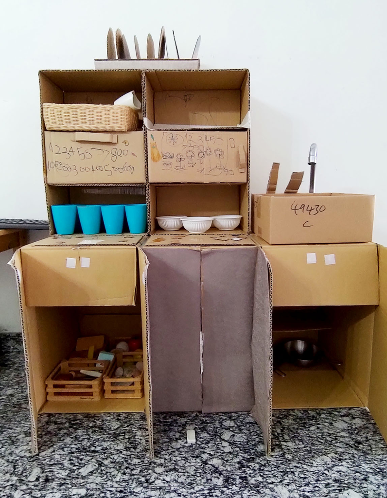

The kids’ kitchen, made out of diaper cartons

The second post-PhD month is now ending, and I am facing the opposite problem: my brain is not in science mode; I get distracted easily. But this seems to be an easier problem that will go away soon.

Finishing a PhD is hard. As it turns out, having finished one is not easy either. Especially in a pandemic—I would have booked a trip somewhere if I could have. But as with most life stage transitions, it takes time. I’m still excited about what lies ahead.